# 002_sentiment_analysis

## Movie reviews - Sentiment Analysis

#### MSDS 7337 - Natural Language Processing - Homework 08

#### 06-Dec-2018

| You have to develop your whole game to completion. |
| --- |
| -- Isaiah Thomas |

### Assignment description

Perform a vocabulary-based sentiment analysis of the movie reviews you used in homework 5 and homework 7, by doing the following :

1. In Python, load one of the sentiment vocabularies referenced in the textbook, and run the sentiment analyzer as explained in the corresponding reference. Add words to the sentiment vocabulary, if you think you need to, to better fit your particular text collection.
2. For each of the clusters you created in homework 7, compute the average, median, high, and low sentiment scores for each cluster. Explain whether you think this reveals anything interesting about the clusters.
3. For extra credit, analyze sentiment of chunks as follows :  
   a. Take the chunks from homework 5, and in Python, run each chunk individually through your sentiment analyzer that you used in question 1. If the chunk registers a nonneutral sentiment, save it in a tabular format (the chunk, the sentiment score).  
   b. Now sort the table twice, once to show the highest negative-sentiment-scoring chunks at the top and again to show the highest positive-sentiment-scoring chunks at the top. Examine the upper portions of both sorted lists, to identify any trends, and explain what you see.

Submit all of your inputs and outputs and your code for this assignment, along with a brief written explanation of your findings.

### Data preparation, feature construction

- 100 movie reviews were downloaded from the IMDB web-site
- the reviews (approx 25 reviews each) are associated to four different films :
  - Stranger Than Paradise, Fargo, The Big Lebowski, and Small Apartments
    - these four films were chosen from the base category drama
    - each of these films has a certain cult following for its unique quirkiness
    - two of these films (Lebowski and Fargo) are Coen Brothers films
- **prior to clustering**, the text from each review was normalized in the following method :
  - contractions expanded
  - part of speech tagged
  - lemmatized, using the part of speech tags in WordNet
  - special characters removed
  - stop words removed, using NLTK english stop words
    - a small list of additional stop words were added to base list, to remove terms that are common in film reviews, e.g., film, movie, cinema, scene, and similar common terms
  - features were developed using TF-IDF feature matrix
  - the feature matrix was used for non-supervised learning using k-means clustering method
- **prior to semantic analysis**, the only normalization of the text from each review was to remove any remaining special characters. we have observed from prior analyses that different verb tenses can carry different sentiments; therefore, all vocabulary was retained in native form for this analysis

### Clustering - k-means

- normalize_corpus() - returns all text values in corpus, regardless of part of speech
- based on results from previous assignment, we use number of clusters = 4

### Sentiment Analysis

- sentiment analysis was completed for each text of each reivew
- methods used included :
  - afinn,
  - sentiwordnet from nltk package, and
  - SentimentIntensityAnalyzer from nltk.vader
- the numerical overall score from each method was retained
- the summary statistics for each method for each cluster are shown in below table
- a plot of the range of sentiment scores plotted vs. the film rating that accompanied the review for each sentiment score is also presented below

### Summary / Observations

To gain some further (slight) insight into relationship between sentiment scores and review rating, at the conclusion of this document are scatter plots showing the individual relationships between each review and its associate sentiment score, for each scoring method

- the plots show a general trend of increasing positive sentiment with the highest film ratings, and at the same time there is significant scatter in these plots, demonstrating that there is not a strong correlation for these cases, in the manner in which the sentiment scoring was conducted
- of the 3 scoring methods, the Afinn method has the strongest general tendency to have increasing positive sentiment with increasing film ratings, for the film reviews that are greater then 5 of 10 on the rating scale. this appears to be indepndent of the cluster association.

### Summary Table of Sentiment Scores and Review Ratings

| cluster | vader_score min | vader_score mean | vader_score median | vader_score max | review_rating min | review_rating mean | review_rating median | review_rating max | swn_score min | swn_score mean | swn_score median | swn_score max | afinn_score min | afinn_score mean | afinn_score median | afinn_score max |
| --- | --- | --- | --- | --- | --- | --- | --- | --- | --- | --- | --- | --- | --- | --- | --- | --- |
| 0 | -0.83 | 0.848235 | 0.980 | 1.0 | 2.0 | 7.769231 | 10.0 | 10.0 | -0.00 | 0.042353 | 0.050 | 0.08 | -5.0 | 23.058824 | 20.0 | 55.0 |
| 1 | -1.00 | 0.734500 | 0.945 | 1.0 | 1.0 | 7.947368 | 9.0 | 10.0 | -0.01 | 0.030000 | 0.020 | 0.09 | -55.0 | 13.350000 | 16.0 | 50.0 |
| 2 | -0.98 | 0.640667 | 0.940 | 1.0 | 1.0 | 6.678571 | 8.0 | 10.0 | -0.05 | 0.022000 | 0.025 | 0.08 | -16.0 | 9.300000 | 10.5 | 43.0 |
| 3 | -0.26 | 0.792353 | 0.960 | 1.0 | 1.0 | 7.266667 | 8.0 | 10.0 | -0.04 | 0.010588 | 0.010 | 0.07 | -2.0 | 19.176471 | 13.0 | 59.0 |

### Reference :

The methods used in this evaluation are based on the methods outlined in "Text Analytics with Python", Sarker, Chapters 6 and 7.

Basis of code for sentiment analysis is maintained at :

https://github.com/dipanjanS/text-analytics-with-python/tree/master/Old_Edition_v1/notebooks/Ch07_Semantic_and_Sentiment_Analysis

```python
from IPython.core.interactiveshell import InteractiveShell
InteractiveShell.ast_node_interactivity = "all"
```

```python
# ... -=-=-=-=-=-=-=-=-=-=-=-=-=-=-=-=-=-=-=-=-=-=-=-=-=-=-=-=-=-=-=-=-
# ... report platform
# ... -=-=-=-=-=-=-=-=-=-=-=-=-=-=-=-=-=-=-=-=-=-=-=-=-=-=-=-=-=-=-=-=-

import platform; print platform.platform()
```

```
Linux-4.15.0-42-generic-x86_64-with-Ubuntu-16.04-xenial
```

```python
# ... -=-=-=-=-=-=-=-=-=-=-=-=-=-=-=-=-=-=-=-=-=-=-=-=-=-=-=-=-=-=-=-=-
# ... load packages
# ... -=-=-=-=-=-=-=-=-=-=-=-=-=-=-=-=-=-=-=-=-=-=-=-=-=-=-=-=-=-=-=-=-

import os
from os import path

import sys; print "Python", sys.version
reload(sys)
sys.setdefaultencoding('utf8')

import timeit
import time
import re; print "re", re.__version__

import numpy as np
import pandas as pd
import statistics

import warnings
warnings.filterwarnings("ignore")

import string
import unicodedata
import pattern
import collections

from tabulate import tabulate

from tqdm import tqdm

import nltk; print "nltk", nltk.__version__
from nltk.corpus import PlaintextCorpusReader
from nltk.probability import ConditionalFreqDist
from nltk.tokenize import word_tokenize, sent_tokenize
from nltk.stem import WordNetLemmatizer
from nltk.corpus import sentiwordnet as swn

from sklearn.decomposition import NMF, LatentDirichletAllocation, TruncatedSVD
from sklearn.feature_extraction.text import CountVectorizer
from sklearn.manifold import TSNE
```

```python
# ... -=-=-=-=-=-=-=-=-=-=-=-=-=-=-=-=-=-=-=-=-=-=-=-=-=-=-=-=-=-=-=-=-
# ... add plot utilities
# ... -=-=-=-=-=-=-=-=-=-=-=-=-=-=-=-=-=-=-=-=-=-=-=-=-=-=-=-=-=-=-=-=-

get_ipython().magic('matplotlib inline')
import matplotlib.pyplot as plt
from matplotlib import rcParams

plt.style.use('seaborn-whitegrid')

rcParams.update({'figure.autolayout': True})
plt.rc('xtick', labelsize=20)
plt.rc('ytick', labelsize=20)
```

```python
# ... -=-=-=-=-=-=-=-=-=-=-=-=-=-=-=-=-=-=-=-=-=-=-=-=-=-=-=-=-=-=-=-=-
# ... support importing other ipynb notebooks
# ... -=-=-=-=-=-=-=-=-=-=-=-=-=-=-=-=-=-=-=-=-=-=-=-=-=-=-=-=-=-=-=-=-

import import_ipynb
```

```python
# ... -=-=-=-=-=-=-=-=-=-=-=-=-=-=-=-=-=-=-=-=-=-=-=-=-=-=-=-=-=-=-=-=-
# ... set some options
# ... -=-=-=-=-=-=-=-=-=-=-=-=-=-=-=-=-=-=-=-=-=-=-=-=-=-=-=-=-=-=-=-=-

%pylab
%matplotlib inline
pd.set_option('max_colwidth',400)


# ... -=-=-=-=-=-=-=-=-=-=-=-=-=-=-=-=-=-=-=-=-=-=-=-=-=-=-=-=-=-=-=-=-
# ... include some local utility functions
# ... -=-=-=-=-=-=-=-=-=-=-=-=-=-=-=-=-=-=-=-=-=-=-=-=-=-=-=-=-=-=-=-=-

def printf(format, *args):
    sys.stdout.write(format % args)

def min_word_length(text, min_length = 2):
    tokens = tokenize_text(text)
    filtered_tokens = [token for token in tokens if len(token) > min_length]
    filtered_text = ' '.join(filtered_tokens)
    return filtered_text

# ref : https://stackoverflow.com/questions/3861674/split-string-by-number-of-words-with-python
def group_words(s, n):
    words = s.split()
    for i in xrange(0, len(words), n):
        yield ' '.join(words[i:i+n])

# ... -=-=-=-=-=-=-=-=-=-=-=-=-=-=-=-=-=-=-=-=-=-=-=-=-=-=-=-=-=-=-=-=-=-=-
# ... character cleaning functions
# ... -=-=-=-=-=-=-=-=-=-=-=-=-=-=-=-=-=-=-=-=-=-=-=-=-=-=-=-=-=-=-=-=-=-=-

def clean_text(start_text) :
    text = [re.sub('^((?![a-zA-Z ]).)*$', '', x) for x in start_text]
    text = [re.sub('_', '', x) for x in text]
    text = [x.lower() for x in text]
    text = [x for x in text if x != '']
    return text


def remove_non_ascii(text):
    L = [32, 44, 46, 65,66,67,68,69,70,71,72,73,74,75,76,77,78,79,80,81,82,83,84,85,86,87,88,89,
         90,97,98,99,100,101,102,103, 104,105,106,107,108,109,110,111,112,113,114,115,116,117,118,119,
         120,121,122]
    text = str(text)
    return ''.join(i for i in text if ord(i) in L)

# ... -=-=-=-=-=-=-=-=-=-=-=-=-=-=-=-=-=-=-=-=-=-=-=-=-=-=-=-=-=-=-=-=-=-=-
# ... print topic features
# ... -=-=-=-=-=-=-=-=-=-=-=-=-=-=-=-=-=-=-=-=-=-=-=-=-=-=-=-=-=-=-=-=-=-=-

def selected_topics(model, vectorizer, top_n=10):

    for idx, topic in enumerate(model.components_):

        print("Topic %d:" % (idx))
        print([(vectorizer.get_feature_names()[i], topic[i])
                        for i in topic.argsort()[:-top_n - 1:-1]])
```

```python
# ... -=-=-=-=-=-=-=-=-=-=-=-=-=-=-=-=-=-=-=-=-=-=-=-=-=-=-=-=-=-=-=-=-=-=-=-=-=-=-=-
# ... import Sarkar functions : https://github.com/dipanjanS/text-analytics-with-python
# ...
# ... (functions modified locally for specific functionality updates)
# ... -=-=-=-=-=-=-=-=-=-=-=-=-=-=-=-=-=-=-=-=-=-=-=-=-=-=-=-=-=-=-=-=-=-=-=-=-=-=-=-

from normalization import *
from featurizer import *
from cluster_utilities import *

from utils import display_evaluation_metrics, display_confusion_matrix, display_classification_report

import normalization_ameliorer
import normalization
import featurizer
import cluster_utilities

reload (normalization_ameliorer)
reload (normalization)
reload (featurizer)
reload (cluster_utilities)
```

```
<module 'normalization_ameliorer' from 'normalization_ameliorer.ipynb'>
```

```
<module 'normalization' from 'normalization.pyc'>
```

```
<module 'featurizer' from 'featurizer.ipynb'>
```

```
<module 'cluster_utilities' from 'cluster_utilities.ipynb'>
```

```python
# ... -=-=-=-=-=-=-=-=-=-=-=-=-=-=-=-=-=-=-=-=-=-=-=-=-=-=-=-=-=-=-=-=-
# ... declare some directory locations
# ... -=-=-=-=-=-=-=-=-=-=-=-=-=-=-=-=-=-=-=-=-=-=-=-=-=-=-=-=-=-=-=-=-

home_dir = "/home/mcdevitt/_ds/_smu/_src/nlp/homework_08"

os.chdir(home_dir)
```

```python
# ... -=-=-=-=-=-=-=-=-=-=-=-=-=-=-=-=-=-=-=-=-=-=-=-=-=-=-=-=-=-=-=-=-
# ... recover reviews data frame
# ... -=-=-=-=-=-=-=-=-=-=-=-=-=-=-=-=-=-=-=-=-=-=-=-=-=-=-=-=-=-=-=-=-

df_imdb = pd.read_pickle('df_imdb_clustered.pkl')

del df_imdb['review_url']

#df_imdb.head()
#df_imdb.tail()
```

```python
from afinn import Afinn
afn = Afinn(emoticons=True)
```

```python
from normalization import normalize_accented_characters, html_parser, strip_html

def analyze_sentiment_sentiwordnet_lexicon(review,
                                           verbose=False):
    # pre-process text

    review = normalize_accented_characters(review)
    review = html_parser.unescape(review)
    review = strip_html(review)

    # tokenize and POS tag text tokens

    text_tokens = nltk.word_tokenize(review)
    tagged_text = nltk.pos_tag(text_tokens)
    pos_score = neg_score = token_count = obj_score = 0

    # get wordnet synsets based on POS tags
    # get sentiment scores if synsets are found

    for word, tag in tagged_text:
        ss_set = None
        if 'NN' in tag and swn.senti_synsets(word, 'n'):
            ss_set = swn.senti_synsets(word, 'n')[0]
        elif 'VB' in tag and swn.senti_synsets(word, 'v'):
            ss_set = swn.senti_synsets(word, 'v')[0]
        elif 'JJ' in tag and swn.senti_synsets(word, 'a'):
            ss_set = swn.senti_synsets(word, 'a')[0]
        elif 'RB' in tag and swn.senti_synsets(word, 'r'):
            ss_set = swn.senti_synsets(word, 'r')[0]

        # if senti-synset is found
        if ss_set:
            # add scores for all found synsets
            pos_score += ss_set.pos_score()
            neg_score += ss_set.neg_score()
            obj_score += ss_set.obj_score()
            token_count += 1

    # aggregate final scores

    final_score = pos_score - neg_score
    norm_final_score = round(float(final_score) / token_count, 2)
    final_sentiment = 'positive' if norm_final_score >= 0 else 'negative'

    if verbose:

        norm_obj_score = round(float(obj_score) / token_count, 2)
        norm_pos_score = round(float(pos_score) / token_count, 2)
        norm_neg_score = round(float(neg_score) / token_count, 2)

        # to display results in a nice table

        sentiment_frame = pd.DataFrame([[final_sentiment, norm_obj_score,
                                         norm_pos_score, norm_neg_score,
                                         norm_final_score]],
                                         columns=pd.MultiIndex(levels=[['SENTIMENT STATS:'],
                                                                      ['Predicted Sentiment', 'Objectivity',
                                                                       'Positive', 'Negative', 'Overall']],
                                                              labels=[[0,0,0,0,0],[0,1,2,3,4]]))
        print sentiment_frame

#    return final_sentiment
    return norm_final_score
```

```python
from nltk.sentiment.vader import SentimentIntensityAnalyzer

def analyze_sentiment_vader_lexicon(review,
                                    threshold=0.1,
                                    verbose=False):
    # pre-process text
    review = normalize_accented_characters(review)
    review = html_parser.unescape(review)
    review = strip_html(review)
    # analyze the sentiment for review
    analyzer = SentimentIntensityAnalyzer()
    scores = analyzer.polarity_scores(review)
    # get aggregate scores and final sentiment
    agg_score = scores['compound']
    final_sentiment = 'positive' if agg_score >= threshold\
                                   else 'negative'
    if verbose:

        # display detailed sentiment statistics

        positive = str(round(scores['pos'], 2)*100)+'%'
        final = round(agg_score, 2)
        negative = str(round(scores['neg'], 2)*100)+'%'
        neutral = str(round(scores['neu'], 2)*100)+'%'
        sentiment_frame = pd.DataFrame([[final_sentiment, final, positive,
                                        negative, neutral]],
                                        columns=pd.MultiIndex(levels=[['SENTIMENT STATS:'],
                                                                      ['Predicted Sentiment', 'Polarity Score',
                                                                       'Positive', 'Negative',
                                                                       'Neutral']],
                                                              labels=[[0,0,0,0,0],[0,1,2,3,4]]))
        print sentiment_frame

#    return final_sentiment
    return final
```

```python
# ... -=-=-=-=-=-=-=-=-=-=-=-=-=-=-=-=-=-=-=-=-=-=-=-=-=-=-=-=-=-=-
# ... sentiment scores, 3-ways
# ... -=-=-=-=-=-=-=-=-=-=-=-=-=-=-=-=-=-=-=-=-=-=-=-=-=-=-=-=-=-=-

afinn_score = []
swn_score = []
vader_score = []

print '*'*80
for review in df_imdb['review_desc'] :
    text = remove_special_characters(review)

# ... afinn
    a_score = afn.score(text)
    afinn_score.append(a_score)

# ... sentiwordnet
    swn_overall_score = analyze_sentiment_sentiwordnet_lexicon(text, verbose = True)
    swn_score.append(swn_overall_score)

# ... vader
    final_score = analyze_sentiment_vader_lexicon(text, threshold = 0.1, verbose = True)
    vader_score.append(final_score)


# ... add scores to main data frame

df_imdb['afinn_score'] = afinn_score
df_imdb['swn_score'] = swn_score
df_imdb['vader_score'] = vader_score

df_imdb.head()
df_imdb.tail()


# ... -=-=-=-=-=-=-=-=-=-=-=-=-=-=-=-=-=-=-=-=-=-=-=-=-=-=-=-=-=-=-
# ... aggregate sentiment scores for each cluster
# ... -=-=-=-=-=-=-=-=-=-=-=-=-=-=-=-=-=-=-=-=-=-=-=-=-=-=-=-=-=-=-

summary_table = df_imdb.groupby(['cluster']).agg({'review_rating' : [min, mean, median, max],
                                  'afinn_score': [min, mean, median, max],
                                  'swn_score': [min, mean, median, max],
                                  'vader_score': [min, mean, median, max]})

summary_table

from tabulate import tabulate
summary_table.to_html('summary_table.html')
```

| cluster | vader_score min | vader_score mean | vader_score median | vader_score max | review_rating min | review_rating mean | review_rating median | review_rating max | swn_score min | swn_score mean | swn_score median | swn_score max | afinn_score min | afinn_score mean | afinn_score median | afinn_score max |
| --- | --- | --- | --- | --- | --- | --- | --- | --- | --- | --- | --- | --- | --- | --- | --- | --- |
| 0 | -0.83 | 0.848235 | 0.980 | 1.0 | 2.0 | 7.769231 | 10.0 | 10.0 | -0.00 | 0.042353 | 0.050 | 0.08 | -5.0 | 23.058824 | 20.0 | 55.0 |
| 1 | -1.00 | 0.734500 | 0.945 | 1.0 | 1.0 | 7.947368 | 9.0 | 10.0 | -0.01 | 0.030000 | 0.020 | 0.09 | -55.0 | 13.350000 | 16.0 | 50.0 |
| 2 | -0.98 | 0.640667 | 0.940 | 1.0 | 1.0 | 6.678571 | 8.0 | 10.0 | -0.05 | 0.022000 | 0.025 | 0.08 | -16.0 | 9.300000 | 10.5 | 43.0 |
| 3 | -0.26 | 0.792353 | 0.960 | 1.0 | 1.0 | 7.266667 | 8.0 | 10.0 | -0.04 | 0.010588 | 0.010 | 0.07 | -2.0 | 19.176471 | 13.0 | 59.0 |

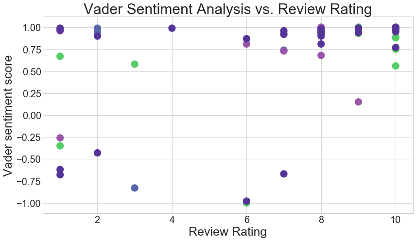

```python
# https://stackoverflow.com/questions/8202605/matplotlib-scatterplot-colour-as-a-function-of-a-third-variable
def pltcolor(lst):
    cols=[]
    for l in lst:
        if l == 0 :
            cols.append('#5566aa')
        elif l == 1:
            cols.append('#55cc66')
        elif l == 2:
            cols.append('#553399')
        else:
            cols.append('#9955aa')
    return cols


# ... -=-=-=-=-=-=-=-=-=-=-=-=-=-=-=-=-=-=-=-=-=-=-=-=-=-=-=-=-=-=-=-=-=-=-
# ... plot -- scatter plots
# ... -=-=-=-=-=-=-=-=-=-=-=-=-=-=-=-=-=-=-=-=-=-=-=-=-=-=-=-=-=-=-=-=-=-=-

# ... make some basic plots to visualize in comparison to film rating

vader = df_imdb['vader_score']
afinn = df_imdb['afinn_score']
swn = df_imdb['swn_score']
rating = df_imdb['review_rating']
cluster = df_imdb['cluster']

# Create the colors list using the function above
cols = pltcolor(cluster)

_ = plt.figure(figsize = (12, 7))
plt.scatter(rating, vader, c = cols, s = 200)
#plt.legend(loc='upper left', fontsize = '25')
plt.title('Vader Sentiment Analysis vs. Review Rating', fontsize = '30')
plt.xlabel('Review Rating', fontsize = '25')
plt.ylabel('Vader sentiment score', fontsize = '25')

axes = plt.gca()
#axes.set_ylim([1, 7])

plt.savefig('vader.png')
plt.show()
```

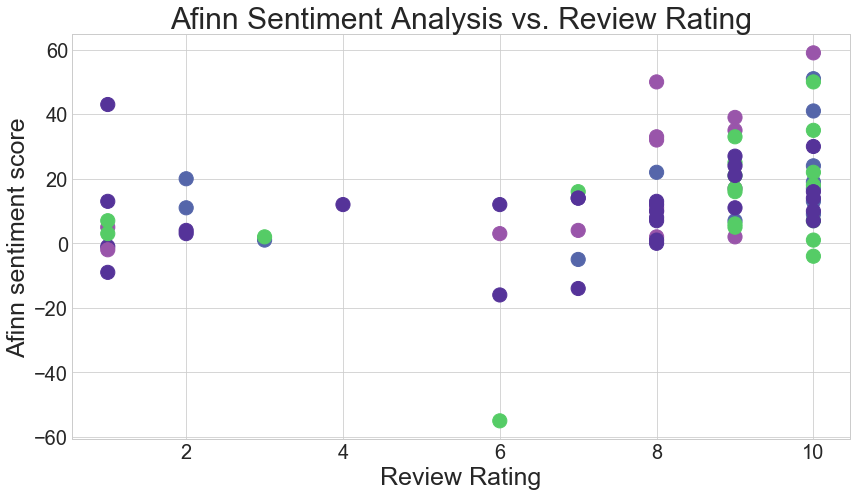

```python
_ = plt.figure(figsize = (12, 7))
plt.scatter(rating, afinn, c = cols, s = 200)
#plt.legend(loc='upper left', fontsize = '25')
plt.title('Afinn Sentiment Analysis vs. Review Rating', fontsize = '30')
plt.xlabel('Review Rating', fontsize = '25')
plt.ylabel('Afinn sentiment score', fontsize = '25')

axes = plt.gca()
#axes.set_ylim([1, 7])

plt.savefig('afinn.png')
plt.show()
```

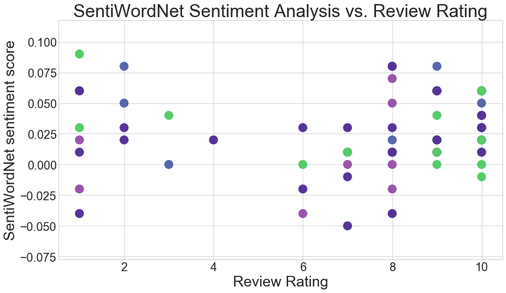

```python
_ = plt.figure(figsize = (12, 7))
plt.scatter(rating, swn, c = cols, s = 200)
#plt.legend(loc='upper left', fontsize = '25')
plt.title('SentiWordNet Sentiment Analysis vs. Review Rating', fontsize = '30')
plt.xlabel('Review Rating', fontsize = '25')
plt.ylabel('SentiWordNet sentiment score', fontsize = '25')

axes = plt.gca()
#axes.set_ylim([1, 7])

plt.savefig('swn.png')
plt.show()
```